# baseballr Presentation

Ian Curtis

2022-11-06

# Load Packages

I first load the necessary packages.

```r
library(baseballr)
library(tidyverse)
```

# Introduction

`baseballr` is a package used to collect data on various baseball (MLB) statistics from multiple sources on the internet. It can also provide some interesting data on pre-selected trends and certain calculations.

As of October 2022, `baseballr` is capable of fetching data from the following sources:

- The MLB API
- The MLB Statcast database (Baseball Savant)
- Retrosheet
- NCAA
- Baseball Reference
- FanGraphs

This package is incredibly useful for searching for MLB data, especially when dataset joining is needed (such as combining statistics from Baseball Reference and FanGraph, for instance).

# Demonstration

Below are a few ways in which the `baseballr` package might be used to grab data.

## Statcast (Baseball Savant)

The [Savant database](https://baseballsavant.mlb.com/) is a large, searchable repository of MLB data extending back to 2008. The database can be searched on the web and contains a large number of custom filters to apply. The database will automatically create aggregate summaries according to selections, but the raw data is pitch-by-pitch and gives the researcher much freedom when using the data.

The package here will grab raw data based on the query which can either specify a specific batter or pitcher or request all of the raw data between a certain time frame.

```r
# Search for all data for Max Scherzer in June 2021

scherzer <- statcast_search_pitchers(
  start_date = '2021-06-01',
  end_date = '2021-06-30',
  pitcherid = 453286)
head(scherzer)
```

```
## # A tibble: 6 × 92
##   pitch_type game_date  release_…¹ relea…² relea…³ playe…⁴ batter pitcher events
##   <chr>      <date>          <dbl>   <dbl>   <dbl> <chr>    <dbl>   <dbl> <chr>
## 1 FF         2021-06-27       95     -3.26    5.59 Scherz… 542932  453286 "stri…
## 2 CH         2021-06-27       84.3   -3.38    5.22 Scherz… 542932  453286 ""
## 3 FF         2021-06-27       94.6   -3.16    5.52 Scherz… 542932  453286 ""
## 4 SL         2021-06-27       85.8   -3.39    5.19 Scherz… 542932  453286 ""
## 5 FF         2021-06-27       95.5   -3.18    5.5  Scherz… 542932  453286 ""
## 6 CH         2021-06-27       83.2   -3.29    5.41 Scherz… 542932  453286 ""
## # … with 83 more variables: description <chr>, spin_dir <lgl>,
## #   spin_rate_deprecated <lgl>, break_angle_deprecated <lgl>,
## #   break_length_deprecated <lgl>, zone <dbl>, des <chr>, game_type <chr>,
## #   stand <chr>, p_throws <chr>, home_team <chr>, away_team <chr>, type <chr>,
## #   hit_location <int>, bb_type <chr>, balls <int>, strikes <int>,
## #   game_year <int>, pfx_x <dbl>, pfx_z <dbl>, plate_x <dbl>, plate_z <dbl>,
## #   on_3b <dbl>, on_2b <dbl>, on_1b <dbl>, outs_when_up <int>, inning <dbl>, …
```

The above chunk searches for all of the pitch-by-pitch data for Max Scherzer in June 2021. The result is a large data frame containing attributes that can be pulled out for use.

From here, we might plot some data!

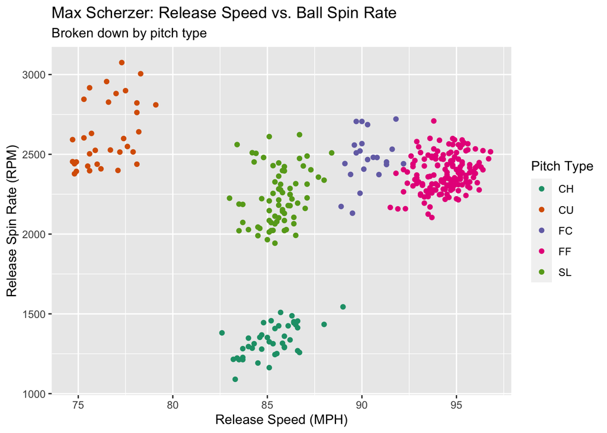

```r
scherzer_plot <- scherzer %>%
  ggplot(aes(x = release_speed, y = release_spin_rate, color = pitch_type)) +
  geom_point() +
  labs(title = 'Max Scherzer: Release Speed vs. Ball Spin Rate',
       subtitle = 'Broken down by pitch type',
       x = 'Release Speed (MPH)',
       y = 'Release Spin Rate (RPM)') +
  guides(color = guide_legend(title = "Pitch Type")) +
  scale_color_brewer(palette = "Dark2")

scherzer_plot
```

## Baseball Reference

Baseball Reference is another source of baseball data. The package `baseballr` allows for aggregate player performance data to be scraped as well as historical standings at any date. There is also a function to calculate “team consistency”. Baseball Reference might be used more for getting “typical” statistics such as batting average, ERA, and number of home runs.

```r
bref_batter <- bref_daily_batter("2021-06-01", "2021-06-30")

head(bref_batter)
```

```
## # A tibble: 6 × 30
##   bbref_id season Name       Age Level Team      G    PA    AB     R     H   X1B
##   <chr>     <int> <chr>    <dbl> <chr> <chr> <dbl> <dbl> <dbl> <dbl> <dbl> <dbl>
## 1 547989     2021 Jose Al…    31 Maj-… Hous…    27   129   101    24    26    13
## 2 660670     2021 Trea Tu…    28 Maj-… Wash…    28   123   113    24    39    27
## 3 642715     2021 DJ LeMa…    32 Maj-… New …    26   123   113    12    33    24
## 4 571431     2021 Freddie…    31 Maj-… Atla…    28   122   108    20    33    23
## 5 656180     2021 Marcus …    30 Maj-… Toro…    26   122   110    24    29    15
## 6 501303     2021 Jonatha…    24 Maj-… Cinc…    27   121    99    24    30    21
## # … with 18 more variables: X2B <dbl>, X3B <dbl>, HR <dbl>, RBI <dbl>,
## #   BB <dbl>, IBB <dbl>, uBB <dbl>, SO <dbl>, HBP <dbl>, SH <dbl>, SF <dbl>,
## #   GDP <dbl>, SB <dbl>, CS <dbl>, BA <dbl>, OBP <dbl>, SLG <dbl>, OPS <dbl>
```

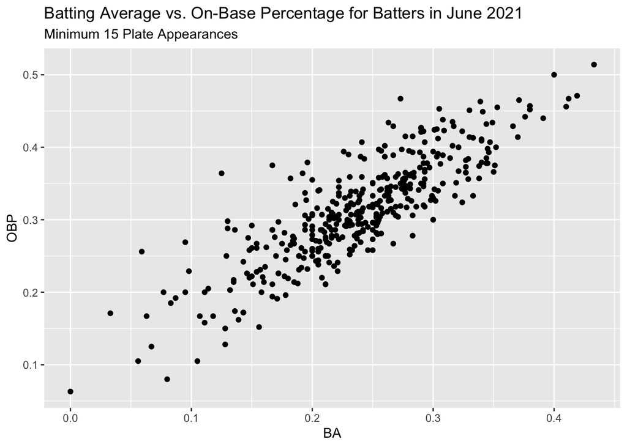

```r
bref_batter %>%
  filter(PA >= 15) %>%
  ggplot(aes(x = BA, y = OBP)) +
  geom_point() +
  labs(title = 'Batting Average vs. On-Base Percentage for Batters in June 2021',
       subtitle = 'Minimum 15 Plate Appearances')
```

# References

- https://baseballsavant.mlb.com/
- https://razzball.com/mlbamids/
- https://www.baseball-reference.com/
- https://billpetti.github.io/baseballr/index.html